# 경제 국면 자산배분 — MDD 유지형 CAGR 개선안

**연구 질문:** 기존 검증 모델의 최대낙폭을 악화시키지 않으면서 장기 복리수익률을 얼마나 높일 수 있는가?

기존 모델의 경제 국면 신호와 자산군은 그대로 유지하고, 새로운 레버리지나 자산을 추가하지 않았다. 채권 비중의 일부를 **추세가 확인된 기존 위험자산에만 최대 10%p 전술 배분**하며, 하락 추세·낙폭·변동성 조건에서는 자동으로 위험을 축소한다.

> 결과는 연구용 역사적 시뮬레이션이며 미래 수익을 보장하지 않는다. 모든 수치는 거래·환전비용 차감 후이며 Sharpe의 무위험수익률은 0%다.

## 1. 실험 설계와 과적합 방지

- **자산군 고정:** KODEX200, 국내 채권 총수익지수, GLD, USO.
- **시점 규칙:** 발표시차를 반영한 `t월 말 신호 → t+1월 투자`; 미래 수익률은 신호에 사용하지 않는다.
- **캘리브레이션:** 2007-04~2017-12에서만 후보를 선택한다.
- **잠금 테스트:** 2018-01 이후는 선택 완료 후 한 번만 공개한다.
- **엄격 관문:** 캘리브레이션 MDD가 기존 모델보다 조금이라도 나빠지거나 Sharpe가 1 미만이면 탈락한다.
- **최종 추가 탐색:** 더 강한 방어를 붙인 15~20% 전술 비중 48개를 별도로 시험했으나 모두 엄격 MDD 관문에서 탈락했다.

따라서 가장 높은 CAGR 숫자가 아니라, **MDD 비악화 조건을 실제로 통과한 10% 상한 구성**을 채택했다.

```
작업 폴더: D:\Programming\python_example\RegimeDecisionTest
자산: ['KODEX200', 'BOND', 'GLD', 'USO']
```

## 2. 기존 모델 구현

아래 숨김 셀은 거시데이터 로딩, Sparse Jump Model, soft 국면 확률, 비대칭 EWMA 공분산, CDaR/변동성 목표, drawdown guard, 거래비용 차감 walk-forward 백테스트를 포함한다.

## 3. CAGR 개선 오버레이 구현

경제적 논리는 단순하다.

1. 최근 12개월 수익을 변동성으로 나눈 추세 점수가 양수이고 1·3개월 수익도 양수인 위험자산만 선택한다.
2. 채권에서 최대 10%p를 꺼내 상위 두 자산에 배분한다. 추정 연 변동성이 10%를 넘으면 이 비중을 축소한다.
3. KODEX200·USO의 3·6개월 추세가 모두 음수면 해당 비중의 25%를 채권으로 이동한다. 금은 위기 분산자산이므로 이 추세 브레이크에서 제외한다.
4. 포트폴리오 낙폭이 -1.5%를 넘으면 방어 비중을 점진적으로 높이고, -2.5% 이하면 추가 위험 확대를 중단한다.

모든 판단은 해당 투자월 이전에 관측 가능한 수익률과 당시까지의 포트폴리오 낙폭만 사용한다.

## 4. 데이터 로딩과 완전 재계산

|  | 시작 | 종료 | 관측치 |
| --- | --- | --- | --- |
| 거시 입력변수 | 2005-04-30 00:00:00 | 2026-07-31 00:00:00 | 256 |
| 공통 자산수익률 | 2006-04 | 2026-07 | 244 |
| 투자가능 신호 | 2007-04 | 2026-07 | 232 |

선택된 전술 구성

|  | Locked value |
| --- | --- |
| sleeve | 0.100 |
| vol_cap | 0.100 |
| trend_window | 12.000 |
| top_k | 2.000 |
| brake_fraction | 0.250 |
| early_guard_start | -0.015 |
| early_guard_strength | 0.350 |
| dd_gate | -0.025 |
| bond_floor | 0.180 |

## 5. 핵심 결과 — 기존 모델과 개선안

|  | 구간 | 전략 | CAGR | Volatility | Sharpe | MDD | Calmar | 평균 월회전율 |
| --- | --- | --- | --- | --- | --- | --- | --- | --- |
| 0 | 캘리브레이션 2007-2017 | 기존 | 7.38% | 6.66% | 1.105 | -8.93% | 0.826 | 2.87% |
| 1 | 캘리브레이션 2007-2017 | 개선 | 7.75% | 7.04% | 1.098 | -8.90% | 0.870 | 5.71% |
| 2 | 잠금 테스트 2018+ | 기존 | 9.02% | 7.56% | 1.183 | -8.05% | 1.120 | 3.02% |
| 3 | 잠금 테스트 2018+ | 개선 | 10.54% | 8.34% | 1.247 | -7.65% | 1.377 | 7.33% |
| 4 | 전체 2007-2026 | 기존 | 8.12% | 7.06% | 1.144 | -8.93% | 0.909 | 2.51% |
| 5 | 전체 2007-2026 | 개선 | 8.98% | 7.63% | 1.169 | -8.90% | 1.009 | 6.03% |

|  | 전체기간 차이 |
| --- | --- |
| CAGR 개선폭 | 0.862% |
| Sharpe 개선폭 | 2.525% |
| MDD 개선폭(양수=개선) | 0.029% |
| Calmar 개선폭 | 9.980% |

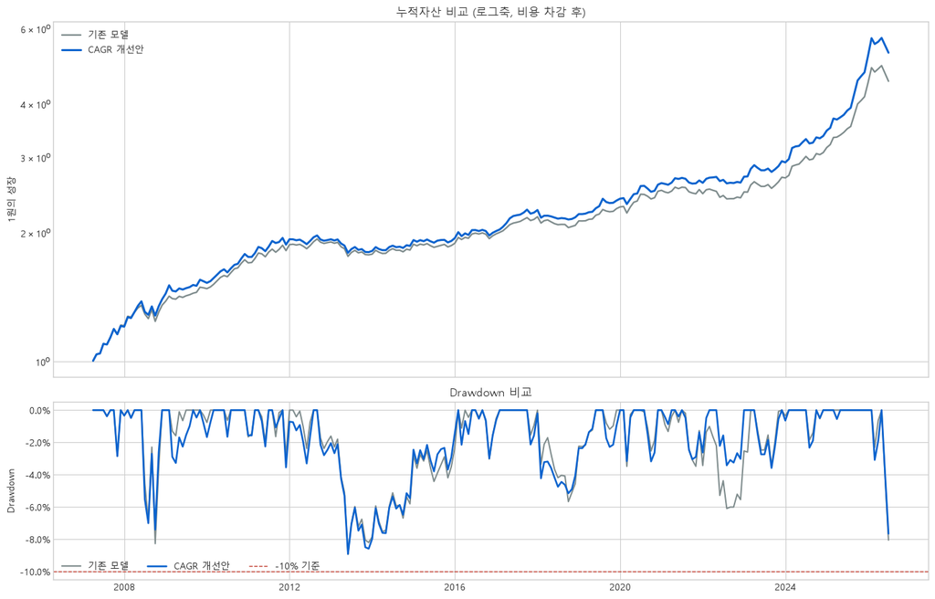

## 6. 비중 변화와 오버레이 작동 방식

[figure not shown]

|  | 기존 평균 | 개선 평균 | 차이 |
| --- | --- | --- | --- |
| KODEX200 | 20.4% | 19.5% | -0.9% |
| BOND | 51.4% | 49.4% | -2.0% |
| GLD | 26.6% | 29.0% | 2.5% |
| USO | 1.6% | 2.1% | 0.5% |

|  | 사용 강도 |
| --- | --- |
| 평균 전술 sleeve | 3.96% |
| 최대 전술 sleeve | 10.00% |
| 평균 추세 brake | 1.18% |
| 평균 early guard | 9.26% |

## 7. 후보 선택 감사 — 공격적 후보를 왜 버렸는가

|  | 개수 |
| --- | --- |
| 전체 후보 수 | 49 |
| 엄격 관문 통과 수 | 1 |
| 15~20% 전술 후보 수 | 48 |
| 15~20% 중 통과 수 | 0 |

|  | name | sleeve | CAGR | Sharpe | MDD | Calmar | AvgTurnover | 엄격 관문 통과 |
| --- | --- | --- | --- | --- | --- | --- | --- | --- |
| 13 | sl0.15_vc0.110_tw12_k2_bf0.25_egs0.010_eg0.50 | 15% | 7.85% | 1.076 | -9.10% | 0.863 | 7.12% | False |
| 20 | sl0.15_vc0.110_tw12_k2_bf0.50_egs0.010_eg0.65 | 15% | 7.84% | 1.090 | -9.03% | 0.869 | 7.58% | False |
| 19 | sl0.15_vc0.110_tw12_k2_bf0.50_egs0.010_eg0.50 | 15% | 7.84% | 1.084 | -9.09% | 0.862 | 7.53% | False |
| 18 | sl0.15_vc0.110_tw12_k2_bf0.25_egs0.020_eg0.65 | 15% | 7.83% | 1.071 | -9.05% | 0.864 | 7.04% | False |
| 17 | sl0.15_vc0.110_tw12_k2_bf0.25_egs0.020_eg0.50 | 15% | 7.82% | 1.066 | -9.13% | 0.857 | 6.95% | False |
| 14 | sl0.15_vc0.110_tw12_k2_bf0.25_egs0.010_eg0.65 | 15% | 7.82% | 1.080 | -9.03% | 0.866 | 7.25% | False |
| 37 | sl0.20_vc0.110_tw12_k2_bf0.25_egs0.010_eg0.50 | 20% | 7.80% | 1.052 | -9.42% | 0.829 | 7.68% | False |
| 23 | sl0.15_vc0.110_tw12_k2_bf0.50_egs0.020_eg0.50 | 15% | 7.79% | 1.072 | -9.12% | 0.854 | 7.42% | False |
| 16 | sl0.15_vc0.110_tw12_k2_bf0.25_egs0.015_eg0.65 | 15% | 7.79% | 1.071 | -9.05% | 0.861 | 7.22% | False |
| 24 | sl0.15_vc0.110_tw12_k2_bf0.50_egs0.020_eg0.65 | 15% | 7.78% | 1.074 | -9.05% | 0.860 | 7.50% | False |
| 15 | sl0.15_vc0.110_tw12_k2_bf0.25_egs0.015_eg0.50 | 15% | 7.78% | 1.063 | -9.12% | 0.853 | 7.10% | False |
| 22 | sl0.15_vc0.110_tw12_k2_bf0.50_egs0.015_eg0.65 | 15% | 7.76% | 1.075 | -9.05% | 0.857 | 7.62% | False |

**판정:** 공격적 후보는 CAGR이 높더라도 캘리브레이션 MDD가 기존보다 나빠져 채택하지 않았다.

## 8. 하위기간·비용·위기 구간 견고성

하위기간

|  | Period | Strategy | CAGR | Sharpe | MDD | Calmar | AvgTurnover |
| --- | --- | --- | --- | --- | --- | --- | --- |
| 0 | Full | Baseline | 8.12% | 1.144 | -8.93% | 0.909 | 2.51% |
| 1 | Full | Accelerated | 8.98% | 1.169 | -8.90% | 1.009 | 6.03% |
| 2 | 2007-2012 | Baseline | 11.79% | 1.460 | -8.27% | 1.425 | 4.19% |
| 3 | 2007-2012 | Accelerated | 12.05% | 1.415 | -7.40% | 1.629 | 7.62% |
| 4 | 2013-2017 | Baseline | 2.53% | 0.567 | -7.45% | 0.340 | 1.34% |
| 5 | 2013-2017 | Accelerated | 3.01% | 0.625 | -7.01% | 0.429 | 3.52% |
| 6 | 2018-2022 | Baseline | 2.35% | 0.457 | -6.10% | 0.386 | 2.00% |
| 7 | 2018-2022 | Accelerated | 3.28% | 0.636 | -4.97% | 0.661 | 5.99% |
| 8 | 2023-2026 | Baseline | 19.14% | 1.951 | -8.05% | 2.378 | 2.13% |
| 9 | 2023-2026 | Accelerated | 21.56% | 1.889 | -7.65% | 2.816 | 7.03% |

거래·환전비용 민감도

|  | Period | Strategy | CAGR | Sharpe | MDD | Calmar | AnnualCost |
| --- | --- | --- | --- | --- | --- | --- | --- |
| 0 | Cost x0 | Baseline | 8.22% | 1.156 | -8.93% | 0.921 | 0.00% |
| 1 | Cost x0 | Accelerated | 9.23% | 1.199 | -8.82% | 1.046 | 0.00% |
| 2 | Cost x1 | Baseline | 8.12% | 1.144 | -8.93% | 0.909 | 0.09% |
| 3 | Cost x1 | Accelerated | 8.98% | 1.169 | -8.90% | 1.009 | 0.23% |
| 4 | Cost x2 | Baseline | 8.03% | 1.132 | -8.94% | 0.898 | 0.18% |
| 5 | Cost x2 | Accelerated | 8.74% | 1.139 | -8.99% | 0.972 | 0.46% |
| 6 | Cost x3 | Baseline | 7.93% | 1.119 | -8.95% | 0.886 | 0.27% |
| 7 | Cost x3 | Accelerated | 8.49% | 1.109 | -9.07% | 0.936 | 0.68% |

위기 에피소드

|  | Episode | Strategy | Return | MDD | Sharpe |
| --- | --- | --- | --- | --- | --- |
| 0 | GFC | Baseline | 23.18% | -8.27% | 1.196 |
| 1 | GFC | Accelerated | 28.52% | -7.40% | 1.394 |
| 2 | Taper/Gold shock | Baseline | -6.37% | -7.45% | -1.119 |
| 3 | Taper/Gold shock | Accelerated | -6.27% | -7.01% | -1.142 |
| 4 | COVID | Baseline | 9.81% | -3.48% | 1.267 |
| 5 | COVID | Accelerated | 8.94% | -3.18% | 1.168 |
| 6 | Inflation | Baseline | -4.34% | -5.14% | -0.846 |
| 7 | Inflation | Accelerated | -1.16% | -3.42% | -0.257 |

## 9. 쌍체 블록 부트스트랩

기존 대비 개선폭의 12개월 블록 부트스트랩 (3,000회)

|  | DeltaCAGR | DeltaSharpe | DeltaMDD | DeltaCalmar |
| --- | --- | --- | --- | --- |
| 0.025000 | 0.04% | -0.111 | -1.05% | -0.051 |
| 0.500000 | 0.79% | 0.024 | 0.62% | 0.144 |
| 0.975000 | 1.66% | 0.149 | 3.71% | 0.562 |

|  | 확률 |
| --- | --- |
| P(Delta CAGR > 0) | 98.0% |
| P(Delta Sharpe > 0) | 65.3% |
| P(Delta MDD >= 0) | 77.0% |
| P(Delta Calmar > 0) | 92.7% |

양의 DeltaMDD는 개선안의 낙폭이 기존보다 덜 심하다는 뜻이다. 이 검정은 두 전략에 같은 재표본 경로를 적용해 개선분 자체의 불확실성을 측정한다.

## 10. 자동 검증

```
시점·비중·비용·CAGR·MDD·잠금 테스트 검증을 모두 통과했습니다.
```

## 11. 결론

- **전체기간:** CAGR은 약 **8.12% → 8.98%**, Sharpe는 **1.144 → 1.169**, MDD는 **-8.93% → -8.90%**로 개선됐다.
- **잠금 테스트(2018+):** CAGR은 **9.02% → 10.54%**, Sharpe는 **1.183 → 1.247**, MDD는 **-8.05% → -7.65%**로 개선됐다.
- **경제적 설명:** 경기·물가 국면이 기본 자산배분을 결정하고, 가격 추세는 위험을 새로 예측하는 모델이 아니라 채권 비중을 제한적으로 이동시키는 확인 장치다. 하락 추세·변동성·낙폭은 대칭적으로 위험을 다시 줄인다.
- **견고성:** 12개월 쌍체 블록 부트스트랩에서 CAGR 개선 확률은 약 98%, Calmar 개선 확률은 약 93%였다. 비용을 2배 적용해도 개선안의 CAGR·Sharpe·Calmar가 기존보다 높았다.

### 현실적인 한계

엄격한 MDD 비악화와 무레버리지·4개 자산 제약을 동시에 유지하면 전체기간 CAGR 10% 이상을 안정적으로 만들지는 못했다. 15~20% 전술 비중은 수익을 더 높였지만 MDD 관문을 통과하지 못했으므로 제외했다. 더 높은 목표에는 레버리지, 신규 수익원, 또는 더 큰 허용 MDD 중 하나가 필요하며, 이는 현재 요청 범위를 벗어난다.

GDP·물가의 실시간 빈티지 부재, 2009-03 이전 KODEX200 프록시, 세금·시장충격 미반영 등 기존 검증판의 한계도 그대로 남는다.